# The ABC of Computational Text Analysis

#4 Introduction to the Command-line

Author

Affiliation

Alex Flückiger

Faculty of Humanities and Social Sciences  
University of Lucerne

Published

March 24, 2023

## Recap last Lecture

- Successful installation? ✅
- Scripting 🎯
  - automate, document, reproduce
- Any questions?
- Installation
  - Installation erfolgreich?
  - unklare Dinge im Guide?
  - Voraussetzung für weitere Sessions
- Projektorganisation zentral
- Scripting bedeutet Organisation
  - iterative Entwicklung
  - Reproduktion
  - Chaos ist nachvollziehbar!

## Outline

- learn principles of the shell 🏛️
- perform shell commands ▶️
- get practice by solving exercises 🏗️
- heute Einführung in Shell, nächstes Mal tatsächlich nützliche Dinge
- Commands statt Klicks
- Wieso Shell (und nicht Python?)
  - wichtig für alle Datei-Operationen, skalierbar für Tausende Dateien
  - manche Programme lassen sich nur über Shell starten
  - einfacher und effizienter als Python, Denken/Konzepte sehr ähnlich
- Shell ist Cockpit bis zu Osterferien
- Metaziel
  - sanfter Einstieg ins Programmieren
  - Verstehen was wichtig ist in Computerinteraktion

## How to get started

### Open a Shell

#### macOS

- open `Terminal`
- shell type: `zsh`

#### Windows

- open `Ubuntu 20.04 LTS`
- shell type: `Bash`
- open Windows Command Prompt
- interaktiv: Studis sollen Bash auch öffnen
  - rasch durchgehen, damit mehr Übungszeit bleibt
- Shell Commands platformübergreifend
- Shell zeigen: Erscheinungsbild je System unterschiedlich

## Bourne-again Shell

### Bash

- offers many built-in tools
- shell prompt
  - `USER@HOSTNAME:~$`
- home directory
  - `~` refers to `/home/USER`
- case-sensitive
- no feedback
  - unless there is an issue

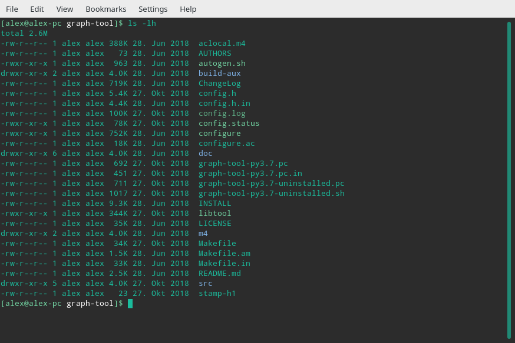

- Computersteuerung komplett über CLI möglich
  - unnütze Verdoppelung zu GUI?
  - ermöglicht Bearbeitung Tausender Dateien
  - schnelle Inspektion von Daten
- Empfehlung: konsequente Nutzung CLI
  - Vertrauen, Geschwindigkeit
  - Anfang braucht Gewöhnung
  - Vorteilen von beiden nutzen
- no need to memorize syntax
  - slides, google, stackoverflow
  - wiederkehrendes auto-erinnern
- Eigenschaften
  - extremely fast
  - kompakter Code -> komplexe Prozessierung

## Unix Philosophy

Build small programs that *do one thing*  
and *do it well*. 🤓

## Basic commands in Shell

### example components of a command

```bash
command -a --long_argument FILE     # non-working example command
```

### run command + help

```bash
echo "hello world"      # print some text
man echo                # get help for any command (e.g., echo)
```

- CLI: Eingabe + Ausgabe gleiches Fenster
- Tradition von hello world
- quotes to preserve formatting
- Hilfeseiten sehr umfangreich
  - googlen oft schneller –> stackoverflow

# Where your files are stored

## … and how to find them

- hierarchical filesystem 🌲
  - folders/directories
  - files with a suffix
- absolute path starting from top-level directory
  - e.g. `/home/alex/KED2023/slides/KED2023_01.html`
- relative path looking from current directory
  - e.g. `KED2023/slides/KED2023_01.html`

```bash
.
├── README.md
└── lectures
    ├── images
    │   └── ai.jpg
    ├── html
    │   ├── KED2023_01.html
    │   └── KED2023_02.html
    └── md
        ├── KED2023_01.md
        └── KED2023_02.md
```

👍 Only relative paths work across systems

- Sehr wichtig und hat in Vergangenheit Probleme bereitet (“Cloud/App-Abstraktion”)
- verschachtelte, hierarchische Struktur
  - wie Aktenschrank mit Ordner
- Navigation in diesem Baum/Aktenschrank (tiefer/höher)
- / für Angabe von Pfad (Verzeichnis/Unterverzeichnis)
- absoluter Pfad beginnt mit Slash, relativer ohne Slash
- Ordner / Dateien –> Endungen
  - keine technische Notwendigkeit

## Important Places in your Filesystem

- shortcut names of directories
  - `.` current dir
  - `..` parent dir
  - `~` home dir (e.g. `/home/alex`)
- find your files on Windows
  - `/mnt/c/Users/YOUR_USERNAME/`
  - shortcut with `documents`
- Windows-Leute hinweisen auf Pfad innerhalb Ubuntu

## Navigating in a File System

```bash
pwd                 # show absolute path of current directory

ls                  # list content of current directory
ls -lh              # list with more information
ls dirname          # list content of directory dirname

cd ..               # change directory to go folder up
cd dir/subdir       # go to folder dir/subdir (two folders down)
```

### when you are lost, open in file manager (GUI)

```bash
open .          # open path in finder (macOS)
explorer.exe .  # open Windows Explorer in WSL Ubuntu (Windows)
```

- Befehle sind Abkürzungen
  - cd = change directory
  - ls = list
- diskutieren von ls output
  - Berechtigung/Eigentümer/Grösse/Mod.-datum/Name
  - d für directory
- beliebige Verzeichnisse springen
  - oberstes Verzeichnis: C: oder /
  - cd zurück ins home
- Kommentare mit #

## Open Files

### show within Shell

```bash
more text.txt           # print content (space to scroll)

head text.txt           # print first 10 lines of file
tail -5 text.txt        # print last 5 lines of file
```

### show with default application (GUI)

```bash
open text.txt           # macOS
wslview text.txt        # WSL Ubuntu (Windows)
```

## Useful Key Actions

- autocompletion: `TAB`
- get last command: ⬆️
- scrolling: `SPACE`
- cancel `CTRL + C`
- quit: `q` or `CTRL + D`
- lange Dateinamen, Programme nur halb erinnert
- q bspw. in Hilfe-Seite man

## Creating, Moving and Copying

### create files and directories

```bash
touch test.txt      # create a new file

mkdir data          # make a new directory
mkdir -p data/1999  # make a new directory with a subfolder
```

### copy and move files

```bash
cp test.txt other/.             # copy file into other folder, keep its name
mv test.txt other/new_name.txt  # move or rename a file
```

- touch abängig, ob Datei existiert
- mkdir -p für Subdirs

## Removing Files

Watch out, there is no recycle bin. No way back!

```bash
rm old.txt          # remove a file
rm -r old_data      # remove a folder with all its files
```

## In-class: Exercises I

1. Create a new directory called `tmp`.
2. Change into that directory using `cd` and print its absolute path using `pwd`.
3. Use `touch` to create a new file called `magic.txt` in `tmp`.
4. Rename the file from `magic.txt` to `easy_as_pie.txt`.
5. Check out the helper page of `mv` command.
6. Look around in the filesystem using `cd` and `ls`.

**Pause**

# How is that useful? 🤔 We are getting there!

## Wildcards

### placeholders to match …

- any single character: `?`
- any sequence of characters: `*`

```bash
mv data/*.txt new_data/.    # move txt-files from to another subfolder
cp *.txt files/.            # copy all txt-files in a single folder
```

- bei Unkenntnis oder Zusammenfassung von Dateinamen
- batch operation
- Ordner muss existieren
  - zeige Fehlermeldung

## Searching

### collect certain files only

```bash
ls *.txt        # list all files with the suffix .txt (in current directory)
```

### find specific files

```bash
# search on filename
find /path/to/dir -name "*speech*"  # find files in specific directory
locate -i pattern_1 pattern_2       # global search of files/folders

# search on content
grep -r "Europe" /path/to/dir       # find all files containing X in a directory
```

- grep ist mächtig, häufig brauchen
- grep nur für rohe Textformate (txt, html, csv etc.)
- arg -i case-insensitiveness

## Expansion

### batch processing with expansion

```bash
touch text_{a..c}.txt
# is equivalent to
touch text_a.txt text_b.txt text_c.txt

mkdir {2000..2005}{a..c}
# is equivalent to
mkdir 2000a 2000b 2000c 2001a 2001b 2001c ...
```

- hilfreich um Dateien zu ordnen

## Operators

- Operators machten Probleme
- modulares Zusammenbauen von Commands
- “Leim” zum Übergeben von Resultaten
- Files als Zwischenprodukte umgehen
- Unix Philosophy

## Combining Commands

### use shell operators to …

- redirect output into file (overwrite): `>`
- append to existing file: `>>`
- stream to next command: `|` (pipe)

```bash
echo 'line 1' > test.txt    # write into file
more test.txt | tail -1     # pass output to next command
```

[Learn more about operators](https://unix.stackexchange.com/questions/159513/what-are-the-shells-control-and-redirection-operators)

- check output first, then overwrite file as a second step

## Merging Files

```bash
cat part_1.txt part_2.txt       # concatenate multiple files
cat *.txt > all_text.txt        # merge all txt into a single one
```

## Conventions 🙏

- no spaces/umlauts in names
  - alphanumeric, underscore, hyphen, dot
- files have a suffix, folders don’t
  - `text_1.txt` vs. `texts`
- descriptive file names
  - `SOURCE/YEAR/speech_party_X.txt`
- don’t modify the raw data
- Konventionen helfen Fehler vermindern, Verständnis verbessern

## Writing a runnable Script

### Example script: `find_all_pdf.sh`

```bash
#!/bin/sh

echo "This is a list of all PDFs on my computer:"
locate -i /home/*.pdf
```

- file with suffix `.sh`
  - one command per row
  - `#` precedes comments
- start script with Shebang `#!/bin/sh`
- execute with `bash SCRIPTNAME.sh`
- Automation = Ablauf von Instruktionen
- Vorteil: nicht nötig Befehlsabfolge zu merken
- Übung ebenfalls als Skript abgeben
- no prompt, just commands

## The beauty of scripting is automation. ⚡

## Assignment #1 ✍️

- get/submit via OLAT
  - starting tonight
  - deadline: 31 March 2023, 23:59
- discuss issues on OLAT forum
- ask friends for support, not solutions
- kleine Übung
- Vertrauen entwickeln
- nicht bis zum Schluss warten

# Questions?

## In-class: Exercises II

1. Create a new file with `touch`.
2. Write the following content into that file, one line at a time using the append operator:

   ```bash
   How about making programming a little more accessible? Like:
   from human_knowledge import solution
   ```

3. Make sure that the content was written into that file using `more`.

## In-class: Exercises III

1. Navigate up and down in in your filesystem using `cd` and list the respective files per directory with `ls`. Where can you find your personal documents? Print the absolute path with `pwd`.  
   A hint to Windows users as they are working in a Ubuntu subsystem, have a look at: `/mnt/c/Users`
2. Read `man ls` and write an `ls` command that lists your documents ordered
   - by recency (time)
   - by size
3. Use the `|` and `>` operators to write the 3 “last modified” files in your documents folder into a file called `last-modified.txt` on your desktop (desktop is also a directory). It is a single command performing multiple operations, one after another.

## Additional Resources

### useful primers on Bash

- [Cheatsheet](https://aflueckiger.github.io/KED2023/materials/cheatsheet_command_line.pdf) for this course
- [The Programming Historian](https://programminghistorian.org/en/lessons/intro-to-bash)
- [DigitalOcean](https://www.digitalocean.com/community/tutorials/an-introduction-to-the-linux-terminal)